# Code used for paper titled *Individual and Census Tract-Level Correlates of Local SARS-CoV-2 Prevalence and Outcomes in Eastern Massachusetts*

This file contains code used to run the statistical analysis used in the paper titled *Individual and Census Tract-Level Correlates of Local SARS-CoV-2 Prevalence and Outcomes in Eastern Massachusetts*. We present the summary statistics for the Census level variables used in this analysis as well as code for running the logistic mixed models for the three SARS-CoV-2 outcomes analyzed in the paper.

# Statistical distribution for census tract variables used in the analysis

Minimum, maximum, mean, median, 25th percentile, 75th percentile, 95th percentile, 99th percentile, and inter-quartile range for all Census tract variables used in this analysis.

```r
census_tract_info <- lab_regression_df %>% select(shape_id,environmental_variables) %>% unique() %>%
  left_join(postgis_2013_2014_census_tract_sf, by='shape_id') %>%
  mutate_at(vars(latitude,longitude),as.numeric) %>% filter(!is.na(latitude)) %>%
  filter(!is.na(longitude))
```

```
## Note: Using an external vector in selections is ambiguous.
## ℹ Use `all_of(environmental_variables)` instead of `environmental_variables` to silence this message.
## ℹ See <https://tidyselect.r-lib.org/reference/faq-external-vector.html>.
```

```r
census_tract_info_df <- st_drop_geometry(census_tract_info) %>% dplyr::select(-shape_id,-latitude,-longitude,-statefip,-geometry)

census_tract_info_df_long <- census_tract_info_df %>% pivot_longer(-geoid)

#ggplot(census_tract_info_df_long, aes(x=value)) + geom_histogram() + facet_wrap(~name,scales = 'free')


census_tract_values_summary <- census_tract_info_df_long %>% group_by(name) %>%
  summarise(min=min(value),
            max=max(value),
            mean=mean(value),
            median=quantile(value, probs=0.5, na.rm=TRUE),
            pct_25=quantile(value, probs=0.25, na.rm=TRUE),
            pct_75=quantile(value, probs=0.75, na.rm=TRUE),
            pct_95=quantile(value, probs=0.95, na.rm=TRUE),
            pct_99=quantile(value, probs=0.99, na.rm=TRUE),
            IQR = IQR(value)
            ) %>%
  round_df(digits = 2)
DT::datatable(census_tract_values_summary)
```

|  | name | min | max | mean | median | pct_25 | pct_75 | pct_95 | pct_99 | IQR |
| --- | --- | --- | --- | --- | --- | --- | --- | --- | --- | --- |
| 1 | asian_pct | 0 | 0.56 | 0.06 | 0.03 | 0.01 | 0.09 | 0.23 | 0.39 | 0.08 |
| 2 | black_pct | 0 | 0.82 | 0.07 | 0.03 | 0.01 | 0.07 | 0.35 | 0.63 | 0.06 |
| 3 | college_pct | 0 | 1 | 0.43 | 0.4 | 0.26 | 0.58 | 0.82 | 0.89 | 0.33 |
| 4 | commute_public_transportation_pct | 0 | 0.72 | 0.11 | 0.05 | 0.02 | 0.15 | 0.39 | 0.5 | 0.14 |
| 5 | commute_vehicle_pct | 0 | 1 | 0.76 | 0.84 | 0.7 | 0.9 | 0.95 | 0.98 | 0.2 |
| 6 | commute_walk_pct | 0 | 0.79 | 0.06 | 0.02 | 0.01 | 0.05 | 0.27 | 0.52 | 0.05 |
| 7 | commute_work_from_home_pct | 0 | 0.77 | 0.05 | 0.04 | 0.02 | 0.07 | 0.12 | 0.18 | 0.04 |
| 8 | essential_worker_pct | 0 | 1 | 0.45 | 0.45 | 0.35 | 0.56 | 0.7 | 0.79 | 0.21 |
| 9 | foreign_born_pct | 0.01 | 0.65 | 0.17 | 0.14 | 0.07 | 0.25 | 0.42 | 0.52 | 0.18 |
| 10 | gini_index | 0.08 | 0.81 | 0.43 | 0.43 | 0.39 | 0.47 | 0.55 | 0.6 | 0.07 |

[output cut: 40 more lines]

# Lab Analysis

Code for analysis of risk of infection with SARS-CoV-2. Risk of infection is based on positivity of viral polymerase chain reaction (PCR) testing for SARS-CoV-2 (lab test).

## Distribution of Age by Race and Primary Language

Age distribution of individuals with positive versus negative lab results for SARS-CoV-2. Individuals also stratified by race and primary language spoken.

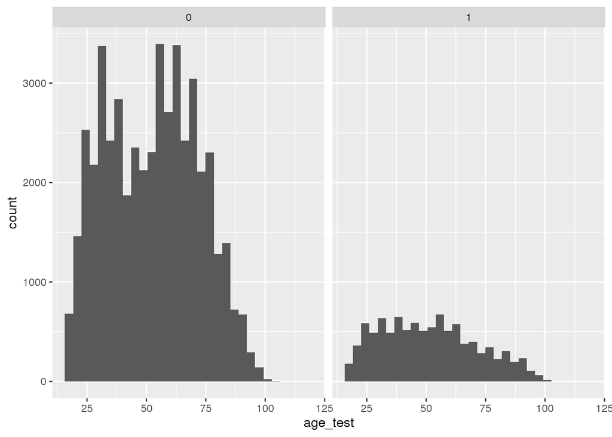

```r
ggplot(lab_regression_df, aes(x=age_test)) +
  geom_histogram() + facet_wrap(~any_pcr_pos)
```

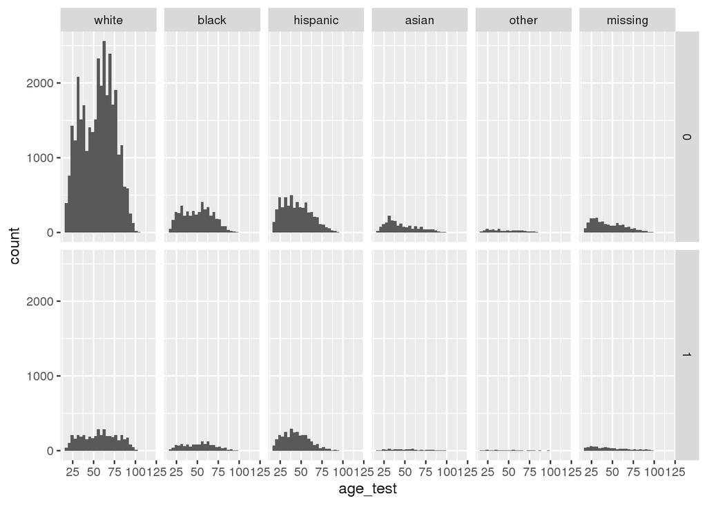

```r
ggplot(lab_regression_df, aes(x=age_test)) +
  geom_histogram() + facet_grid(any_pcr_pos~race_normalized)
```

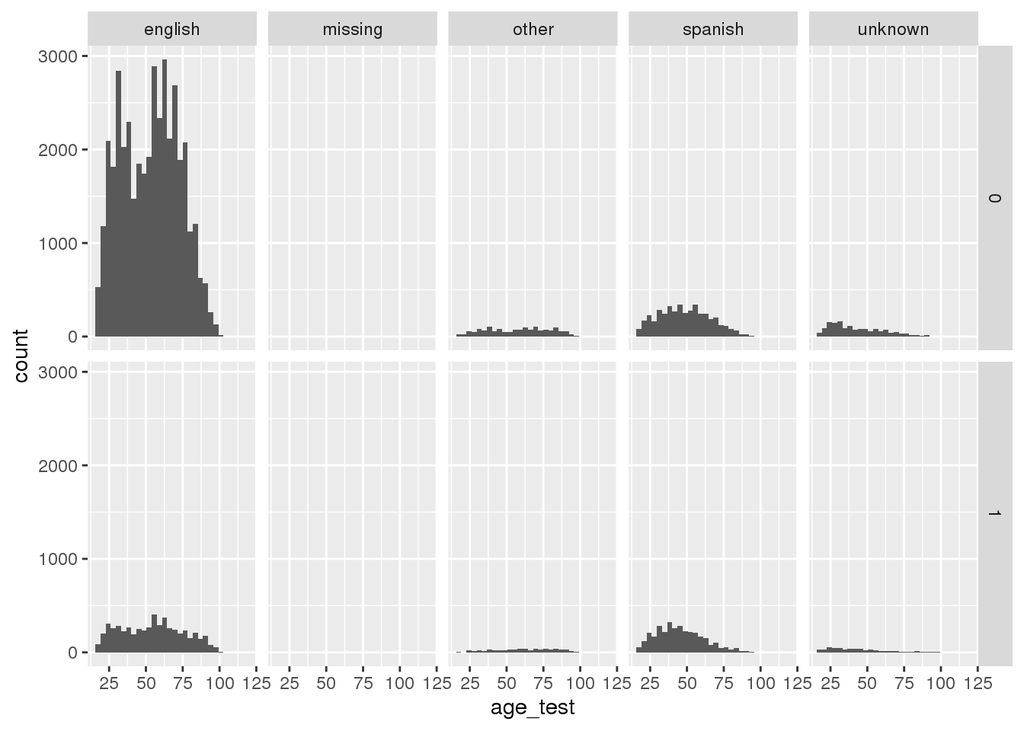

```r
ggplot(lab_regression_df, aes(x=age_test)) +
  geom_histogram() + facet_grid(any_pcr_pos~language_normalized)
```

## Base Model

Code used to run the base model for the SARS-CoV-2 lab test outcome.

```r
lab_matern_base <-  mgcv::gam(
  formula = any_pcr_pos ~
    age_test +
    Gender +
    race_normalized +
    language_normalized +
    inscat1 +
    per_capita_testing +
    s(latitude, longitude, bs='gp', k=350, m=c(3,.01)),
  family = binomial(),
  data = lab_regression_df
)


parameters_lab_matern_base <- parameters(lab_matern_base,exponentiate=TRUE)




saveRDS(parameters_lab_matern_base,
        '/PHShome/cl331/covid_analysis/v3/covid_website/data/parameters_lab_matern_base.rds')
```

### All Coefficients

Model statistics for all variables used in base model.

```r
DT::datatable(round_df(parameters_lab_matern_base, digits = 2))
```

|  | Parameter | Coefficient | SE | CI_low | CI_high | z | df_error | p | Component |
| --- | --- | --- | --- | --- | --- | --- | --- | --- | --- |
| 1 | (Intercept) | 0.05 | 0 | 0.04 | 0.06 | -51.14 | 57701.08 | 0 | conditional |
| 2 | age_test | 1.01 | 0 | 1.01 | 1.01 | 9.01 | 57701.08 | 0 | conditional |
| 3 | GenderM | 1.3 | 0.03 | 1.24 | 1.36 | 10.8 | 57701.08 | 0 | conditional |
| 4 | GenderU | 0.41 | 0.31 | 0.09 | 1.83 | -1.17 | 57701.08 | 0.24 | conditional |
| 5 | race_normalizedblack | 2.22 | 0.09 | 2.06 | 2.4 | 20.33 | 57701.08 | 0 | conditional |
| 6 | race_normalizedhispanic | 1.65 | 0.07 | 1.52 | 1.78 | 12.38 | 57701.08 | 0 | conditional |
| 7 | race_normalizedasian | 1.21 | 0.08 | 1.06 | 1.39 | 2.76 | 57701.08 | 0.01 | conditional |
| 8 | race_normalizedother | 1.61 | 0.18 | 1.3 | 2 | 4.33 | 57701.08 | 0 | conditional |
| 9 | race_normalizedmissing | 1.93 | 0.14 | 1.68 | 2.22 | 9.2 | 57701.08 | 0 | conditional |
| 10 | language_normalizedmissing | 4.28 | 6.14 | 0.26 | 71.27 | 1.01 | 57701.08 | 0.31 | conditional |

[output cut: 8 more lines]

### Coefficients by FDR < 0.05

Model statistics for all variables after filtering (FDR adjusted p-value < 0.05) in base model.

```r
DT::datatable(round_df(parameters_lab_matern_base %>% filter(p < 0.05), digits = 2))
```

|  | Parameter | Coefficient | SE | CI_low | CI_high | z | df_error | p | Component |
| --- | --- | --- | --- | --- | --- | --- | --- | --- | --- |
| 1 | (Intercept) | 0.05 | 0 | 0.04 | 0.06 | -51.14 | 57701.08 | 0 | conditional |
| 2 | age_test | 1.01 | 0 | 1.01 | 1.01 | 9.01 | 57701.08 | 0 | conditional |
| 3 | GenderM | 1.3 | 0.03 | 1.24 | 1.36 | 10.8 | 57701.08 | 0 | conditional |
| 4 | race_normalizedblack | 2.22 | 0.09 | 2.06 | 2.4 | 20.33 | 57701.08 | 0 | conditional |
| 5 | race_normalizedhispanic | 1.65 | 0.07 | 1.52 | 1.78 | 12.38 | 57701.08 | 0 | conditional |
| 6 | race_normalizedasian | 1.21 | 0.08 | 1.06 | 1.39 | 2.76 | 57701.08 | 0.01 | conditional |
| 7 | race_normalizedother | 1.61 | 0.18 | 1.3 | 2 | 4.33 | 57701.08 | 0 | conditional |
| 8 | race_normalizedmissing | 1.93 | 0.14 | 1.68 | 2.22 | 9.2 | 57701.08 | 0 | conditional |
| 9 | language_normalizedother | 1.97 | 0.11 | 1.77 | 2.2 | 12.13 | 57701.08 | 0 | conditional |
| 10 | language_normalizedspanish | 3 | 0.12 | 2.77 | 3.24 | 27.66 | 57701.08 | 0 | conditional |

[output cut: 5 more lines]

## Base Plus Individual Environmental Variables

Code used to run the base-plus model for the SARS-CoV-2 lab test outcome. This model iterates through all Census tract variables and fits a model with base variables plus the Census tract variable.

```r
gam_estimate_base_environmental_variable <- function(environmental_variable, df, formula_matern ){
  df <- df %>% rename(environmental_value=!!environmental_variable)

  model <- gam(formula = formula_matern, data = df,family = binomial())

   parameters_output <- parameters(model,exponentiate=TRUE)

   parameters_output$environmental_variable <- environmental_variable

#   parameters_output_stratified <- df %>% group_by(race_normalized) %>%
  #   do(model_stratified=gam(formula = formula_matern_stratified, data = df,family = binomial())) %>%
  #   parameters(model,exponentiate=TRUE) %>%
  #   mutate(environmental_variable=environmental_variable) %>% ungroup()

  # parameters_output <- parameters_output %>% bind_rows(parameters_output_stratified)
   collinearity_matern_both <- check_collinearity(model, component='conditional')

      collinearity_matern_both$environmental_variable <- environmental_variable


   return(list(parameters=parameters_output,vif_df = collinearity_matern_both ))

}









gam_lab_matern_base_environment <- as.formula(any_pcr_pos ~
    age_test +
    Gender +
    race_normalized +
    language_normalized +
    inscat1 +
    per_capita_testing +
    environmental_value +
    s(latitude, longitude, bs='gp',k=350, m=c(3,.01))
    )




#gam_lab_parameters_base_environment_list <- furrr::future_map(.x=environmental_variables,
#                                                 .f=safely(gam_estimate_base_environmental_variable),
#                                                 df=lab_regression_df,
#                                                 formula_matern=gam_lab_matern_base_environment)










#saveRDS(gam_lab_parameters_base_environment_list, '/PHShome/cl331/covid_analysis/data/v2/gam_lab_parameters_base_environment_list.rds')




gam_lab_parameters_base_environment_list <- readRDS('/PHShome/cl331/covid_analysis/data/v2/gam_lab_parameters_base_environment_list.rds')





list_nums <- 1:length(environmental_variables)







gam_lab_parameters_base_environment_df_subset <- map(.x=list_nums, .f=extract_parameters,df=gam_lab_parameters_base_environment_list) %>%
  bind_rows() %>% filter(Parameter == 'environmental_value')


gam_lab_parameters_base_environment_df_subset_vif <- map(.x=list_nums, .f=extract_vif,df=gam_lab_parameters_base_environment_list) %>%
  bind_rows()












coef_base_plus_rows <- gam_lab_parameters_base_environment_df_subset %>%
  mutate(model='gam_base_plus') %>%
  mutate(Parameter=environmental_variable)
```

### All Coefficients

Model statistics of all Census tract level variables after running all base-plus models.

```r
FDR_df_lab <- coef_base_plus_rows %>%
  filter(!Parameter %in% c('age_test','race_normalizedblack','race_normalizedhispanic',
                           'race_normalizedasian','race_normalizedother','race_normalizedmissing',
                           'language_normalizedother','language_normalizedspanish','language_normalizedunknown',
                           'inscat10','inscat11','inscat12','GenderM','GenderU','per_capita_testing',
                           '(Intercept)'))




FDR_df_lab_fdr <- FDR_df_lab %>%
  mutate(fdr=p.adjust(p, method="fdr")) %>%
  mutate(significance = if_else(fdr < 0.05,'FDR significant', 'FDR not significant'))

#DT::datatable(FDR_df_lab_fdr)

DT::datatable(round_df(FDR_df_lab_fdr, digits=4))
```

|  | Parameter | Coefficient | SE | CI_low | CI_high | z | df_error | p | Component | environmental_variable | model | fdr | significance |
| --- | --- | --- | --- | --- | --- | --- | --- | --- | --- | --- | --- | --- | --- |
| 1 | over_65_all_pct | 0.7072 | 0.22 | 0.3844 | 1.3013 | -1.1135 | 57700.5725 | 0.2655 | conditional | over_65_all_pct | gam_base_plus | 0.3793 | FDR not significant |
| 2 | non_white_pct | 1.8699 | 0.2003 | 1.5158 | 2.3066 | 5.8438 | 57712.1423 | 0 | conditional | non_white_pct | gam_base_plus | 0 | FDR significant |
| 3 | white_pct | 0.5348 | 0.0573 | 0.4335 | 0.6597 | -5.8438 | 57712.1423 | 0 | conditional | white_pct | gam_base_plus | 0 | FDR significant |
| 4 | black_pct | 2.5765 | 0.5027 | 1.7578 | 3.7766 | 4.8511 | 57709.5889 | 0 | conditional | black_pct | gam_base_plus | 0 | FDR significant |
| 5 | asian_pct | 1.0225 | 0.2639 | 0.6165 | 1.6958 | 0.0862 | 57700.1757 | 0.9313 | conditional | asian_pct | gam_base_plus | 0.9322 | FDR not significant |
| 6 | hispanic_pct | 1.888 | 0.3044 | 1.3764 | 2.5897 | 3.941 | 57703.1879 | 0.0001 | conditional | hispanic_pct | gam_base_plus | 0.0005 | FDR significant |
| 7 | foreign_born_pct | 2.2994 | 0.4062 | 1.6265 | 3.2508 | 4.7135 | 57708.7166 | 0 | conditional | foreign_born_pct | gam_base_plus | 0 | FDR significant |
| 8 | pct_private_insurance | 0.5984 | 0.0785 | 0.4627 | 0.7738 | -3.9153 | 57704.0036 | 0.0001 | conditional | pct_private_insurance | gam_base_plus | 0.0005 | FDR significant |
| 9 | pct_medicare_insurance | 0.6461 | 0.2319 | 0.3197 | 1.3057 | -1.2169 | 57700.2506 | 0.2236 | conditional | pct_medicare_insurance | gam_base_plus | 0.3389 | FDR not significant |
| 10 | pct_medicaid_insurance | 1.6775 | 0.2388 | 1.2691 | 2.2172 | 3.6346 | 57704.0491 | 0.0003 | conditional | pct_medicaid_insurance | gam_base_plus | 0.0013 | FDR significant |

[output cut: 40 more lines]

```r
saveRDS(FDR_df_lab_fdr,
        '/PHShome/cl331/covid_analysis/v3/covid_website/data/FDR_df_lab_fdr.rds')
```

### Coefficients filtered by FDR < 0.05

Model statistics of all Census tract level variables (after filtering for coefficients with FDR adjusted p-value < 0.05) after running all base-plus models.

```r
knitr::kable(round_df(FDR_df_lab_fdr %>% filter(significance == 'FDR significant'), digits = 2))
```

| Parameter | Coefficient | SE | CI_low | CI_high | z | df_error | p | Component | environmental_variable | model | fdr | significance |
| --- | --- | --- | --- | --- | --- | --- | --- | --- | --- | --- | --- | --- |
| non_white_pct | 1.87 | 0.20 | 1.52 | 2.31 | 5.84 | 57712.14 | 0.00 | conditional | non_white_pct | gam_base_plus | 0.00 | FDR significant |
| white_pct | 0.53 | 0.06 | 0.43 | 0.66 | -5.84 | 57712.14 | 0.00 | conditional | white_pct | gam_base_plus | 0.00 | FDR significant |
| black_pct | 2.58 | 0.50 | 1.76 | 3.78 | 4.85 | 57709.59 | 0.00 | conditional | black_pct | gam_base_plus | 0.00 | FDR significant |
| hispanic_pct | 1.89 | 0.30 | 1.38 | 2.59 | 3.94 | 57703.19 | 0.00 | conditional | hispanic_pct | gam_base_plus | 0.00 | FDR significant |
| foreign_born_pct | 2.30 | 0.41 | 1.63 | 3.25 | 4.71 | 57708.72 | 0.00 | conditional | foreign_born_pct | gam_base_plus | 0.00 | FDR significant |
| pct_private_insurance | 0.60 | 0.08 | 0.46 | 0.77 | -3.92 | 57704.00 | 0.00 | conditional | pct_private_insurance | gam_base_plus | 0.00 | FDR significant |
| pct_medicaid_insurance | 1.68 | 0.24 | 1.27 | 2.22 | 3.63 | 57704.05 | 0.00 | conditional | pct_medicaid_insurance | gam_base_plus | 0.00 | FDR significant |
| pop_dens_log | 1.28 | 0.06 | 1.17 | 1.40 | 5.28 | 57710.57 | 0.00 | conditional | pop_dens_log | gam_base_plus | 0.00 | FDR significant |
| poverty_under_150_pct | 1.58 | 0.25 | 1.15 | 2.15 | 2.87 | 57702.65 | 0.00 | conditional | poverty_under_150_pct | gam_base_plus | 0.01 | FDR significant |
| poverty_under_200_pct | 1.44 | 0.20 | 1.10 | 1.89 | 2.65 | 57702.37 | 0.01 | conditional | poverty_under_200_pct | gam_base_plus | 0.02 | FDR significant |
| nohs_pct | 3.04 | 0.70 | 1.94 | 4.77 | 4.86 | 57705.02 | 0.00 | conditional | nohs_pct | gam_base_plus | 0.00 | FDR significant |
| college_pct | 0.55 | 0.07 | 0.43 | 0.70 | -4.91 | 57704.09 | 0.00 | conditional | college_pct | gam_base_plus | 0.00 | FDR significant |
| unemployed_pct | 9.54 | 7.06 | 2.23 | 40.73 | 3.04 | 57701.18 | 0.00 | conditional | unemployed_pct | gam_base_plus | 0.01 | FDR significant |
| essential_worker_pct | 1.70 | 0.27 | 1.25 | 2.31 | 3.39 | 57702.47 | 0.00 | conditional | essential_worker_pct | gam_base_plus | 0.00 | FDR significant |
| household_3_plus_pct | 1.55 | 0.23 | 1.16 | 2.06 | 2.98 | 57701.30 | 0.00 | conditional | household_3_plus_pct | gam_base_plus | 0.01 | FDR significant |
| household_4_plus_pct | 1.73 | 0.32 | 1.20 | 2.48 | 2.97 | 57701.09 | 0.00 | conditional | household_4_plus_pct | gam_base_plus | 0.01 | FDR significant |
| household_5_plus_pct | 3.21 | 0.99 | 1.76 | 5.87 | 3.79 | 57701.82 | 0.00 | conditional | household_5_plus_pct | gam_base_plus | 0.00 | FDR significant |
| commute_work_from_home_pct | 0.25 | 0.13 | 0.09 | 0.71 | -2.60 | 57702.27 | 0.01 | conditional | commute_work_from_home_pct | gam_base_plus | 0.02 | FDR significant |
| pop_dens | 1.00 | 0.00 | 1.00 | 1.00 | 3.54 | 57702.59 | 0.00 | conditional | pop_dens | gam_base_plus | 0.00 | FDR significant |

## Multivariate Analysis

```r
lab_matern_fdr_filtered <-  mgcv::gam(
  formula = any_pcr_pos ~
    age_test +
    Gender +
    race_normalized +
    language_normalized +
    inscat1 +
    per_capita_testing +
    black_pct +
    hispanic_pct +
    foreign_born_pct +
    pct_private_insurance +
    pct_medicaid_insurance +
    pop_dens_log +
    poverty_under_150_pct +
    nohs_pct +
    college_pct+
    unemployed_pct +
    essential_worker_pct +
    household_5_plus_pct +
    commute_work_from_home_pct +
    s(latitude, longitude, bs='gp', k=350, m=c(3,.01)),
  family = binomial(),
  data = lab_regression_df
)


parameters_lab_matern_fdr_filtered<- parameters(lab_matern_fdr_filtered,exponentiate=TRUE)




saveRDS(parameters_lab_matern_fdr_filtered,
        '/PHShome/cl331/covid_analysis/v3/covid_website/data/parameters_lab_matern_fdr_filtered.rds')
```

### All Coefficients

Model statistics of all variables used in multivariate model.

```r
DT::datatable(round_df(parameters_lab_matern_fdr_filtered, digits = 2))
```

|  | Parameter | Coefficient | SE | CI_low | CI_high | z | df_error | p | Component |
| --- | --- | --- | --- | --- | --- | --- | --- | --- | --- |
| 1 | (Intercept) | 0.05 | 0.02 | 0.02 | 0.1 | -7.71 | 57702.93 | 0 | conditional |
| 2 | age_test | 1.01 | 0 | 1.01 | 1.01 | 9.29 | 57702.93 | 0 | conditional |
| 3 | GenderM | 1.3 | 0.03 | 1.24 | 1.36 | 10.83 | 57702.93 | 0 | conditional |
| 4 | GenderU | 0.4 | 0.3 | 0.09 | 1.77 | -1.21 | 57702.93 | 0.23 | conditional |
| 5 | race_normalizedblack | 2.15 | 0.09 | 1.99 | 2.32 | 19.29 | 57702.93 | 0 | conditional |
| 6 | race_normalizedhispanic | 1.61 | 0.07 | 1.49 | 1.74 | 11.75 | 57702.93 | 0 | conditional |
| 7 | race_normalizedasian | 1.2 | 0.08 | 1.05 | 1.38 | 2.62 | 57702.93 | 0.01 | conditional |
| 8 | race_normalizedother | 1.59 | 0.18 | 1.28 | 1.98 | 4.23 | 57702.93 | 0 | conditional |
| 9 | race_normalizedmissing | 1.91 | 0.14 | 1.66 | 2.19 | 9.04 | 57702.93 | 0 | conditional |
| 10 | language_normalizedmissing | 4.59 | 6.57 | 0.28 | 75.86 | 1.07 | 57702.93 | 0.29 | conditional |

[output cut: 21 more lines]

### Coefficients by FDR < 0.05

Model statistics of all variables (after filtering for FDR adjusted p-value < 0.05) used in multivariate model.

```r
DT::datatable(round_df(parameters_lab_matern_fdr_filtered %>% filter(p < 0.05), digits = 2))
```

|  | Parameter | Coefficient | SE | CI_low | CI_high | z | df_error | p | Component |
| --- | --- | --- | --- | --- | --- | --- | --- | --- | --- |
| 1 | (Intercept) | 0.05 | 0.02 | 0.02 | 0.1 | -7.71 | 57702.93 | 0 | conditional |
| 2 | age_test | 1.01 | 0 | 1.01 | 1.01 | 9.29 | 57702.93 | 0 | conditional |
| 3 | GenderM | 1.3 | 0.03 | 1.24 | 1.36 | 10.83 | 57702.93 | 0 | conditional |
| 4 | race_normalizedblack | 2.15 | 0.09 | 1.99 | 2.32 | 19.29 | 57702.93 | 0 | conditional |
| 5 | race_normalizedhispanic | 1.61 | 0.07 | 1.49 | 1.74 | 11.75 | 57702.93 | 0 | conditional |
| 6 | race_normalizedasian | 1.2 | 0.08 | 1.05 | 1.38 | 2.62 | 57702.93 | 0.01 | conditional |
| 7 | race_normalizedother | 1.59 | 0.18 | 1.28 | 1.98 | 4.23 | 57702.93 | 0 | conditional |
| 8 | race_normalizedmissing | 1.91 | 0.14 | 1.66 | 2.19 | 9.04 | 57702.93 | 0 | conditional |
| 9 | language_normalizedother | 1.94 | 0.11 | 1.74 | 2.16 | 11.84 | 57702.93 | 0 | conditional |
| 10 | language_normalizedspanish | 2.95 | 0.12 | 2.72 | 3.18 | 27.17 | 57702.93 | 0 | conditional |

[output cut: 9 more lines]

# Inpatient Analysis

Code for analysis of hospitilization due to SARS-CoV-2 conditioned on receiving a positive SARS-CoV-2 lab test.

## Distribution of Race and Age

Age distribution of individuals hospitalized due to SARS-CoV-2 versus not hospitalized due to SARS-CoV-2 (among individuals with a positive SARS-CoV-2 lab test). Individuals also stratified by race and primary language spoken.

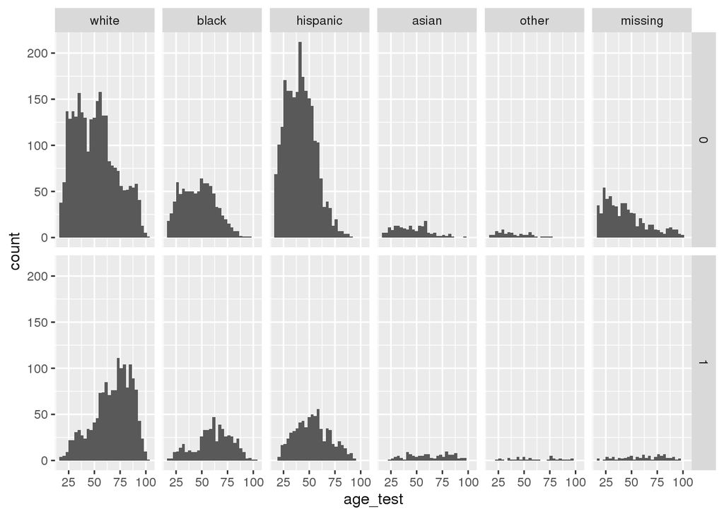

```r
ggplot(inpatient_regression_df, aes(x=age_test)) +
  geom_histogram() + facet_grid(inpatient_flag~race_normalized)
```

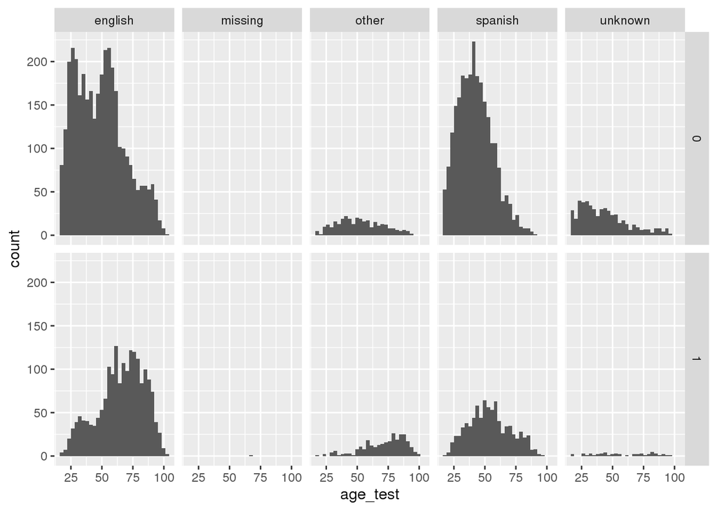

```r
ggplot(inpatient_regression_df, aes(x=age_test)) +
  geom_histogram() + facet_grid(inpatient_flag~language_normalized)
```

## Base Model

Code used to run the base model for the hospitilization due to SARS-CoV-2.

```r
inpatient_matern_base <-  mgcv::gam(
  formula = inpatient_flag ~
    age_test +
    Gender +
    race_normalized +
    language_normalized +
    inscat1 +
    per_capita_testing +
    s(latitude, longitude, bs='gp', k=350, m=c(3,.01)),
  family = binomial(),
  data = inpatient_regression_df
)


parameters_inpatient_matern_base <- parameters(inpatient_matern_base,exponentiate=TRUE)





saveRDS(parameters_inpatient_matern_base,
        '/PHShome/cl331/covid_analysis/v3/covid_website/data/parameters_inpatient_matern_base.rds')
```

### All Coefficients

Model statistics for all variables used in base model.

```r
DT::datatable(round_df(parameters_inpatient_matern_base, digits = 2))
```

|  | Parameter | Coefficient | SE | CI_low | CI_high | z | df_error | p | Component |
| --- | --- | --- | --- | --- | --- | --- | --- | --- | --- |
| 1 | (Intercept) | 0.04 | 0.01 | 0.03 | 0.06 | -21.55 | 9702.1 | 0 | conditional |
| 2 | age_test | 1.04 | 0 | 1.04 | 1.04 | 21.26 | 9702.1 | 0 | conditional |
| 3 | GenderM | 1.51 | 0.08 | 1.37 | 1.67 | 8.14 | 9702.1 | 0 | conditional |
| 4 | GenderU | 0 | 0 | 0 |  | -0.01 | 9702.1 | 0.99 | conditional |
| 5 | race_normalizedblack | 1.36 | 0.11 | 1.16 | 1.6 | 3.83 | 9702.1 | 0 | conditional |
| 6 | race_normalizedhispanic | 0.77 | 0.06 | 0.65 | 0.9 | -3.24 | 9702.1 | 0 | conditional |
| 7 | race_normalizedasian | 1.55 | 0.23 | 1.16 | 2.06 | 2.99 | 9702.1 | 0 | conditional |
| 8 | race_normalizedother | 1.72 | 0.39 | 1.1 | 2.7 | 2.37 | 9702.1 | 0.02 | conditional |
| 9 | race_normalizedmissing | 0.69 | 0.12 | 0.5 | 0.96 | -2.19 | 9702.1 | 0.03 | conditional |
| 10 | language_normalizedmissing | 136989407.39 | 541954803154.74 | 0 |  | 0 | 9702.1 | 1 | conditional |

[output cut: 8 more lines]

### Coefficients by FDR < 0.05

Model statistics for all variables after filtering (FDR adjusted p-value < 0.05) in base model.

```r
DT::datatable(round_df(parameters_inpatient_matern_base %>% filter(p < 0.05), digits = 2))
```

|  | Parameter | Coefficient | SE | CI_low | CI_high | z | df_error | p | Component |
| --- | --- | --- | --- | --- | --- | --- | --- | --- | --- |
| 1 | (Intercept) | 0.04 | 0.01 | 0.03 | 0.06 | -21.55 | 9702.1 | 0 | conditional |
| 2 | age_test | 1.04 | 0 | 1.04 | 1.04 | 21.26 | 9702.1 | 0 | conditional |
| 3 | GenderM | 1.51 | 0.08 | 1.37 | 1.67 | 8.14 | 9702.1 | 0 | conditional |
| 4 | race_normalizedblack | 1.36 | 0.11 | 1.16 | 1.6 | 3.83 | 9702.1 | 0 | conditional |
| 5 | race_normalizedhispanic | 0.77 | 0.06 | 0.65 | 0.9 | -3.24 | 9702.1 | 0 | conditional |
| 6 | race_normalizedasian | 1.55 | 0.23 | 1.16 | 2.06 | 2.99 | 9702.1 | 0 | conditional |
| 7 | race_normalizedother | 1.72 | 0.39 | 1.1 | 2.7 | 2.37 | 9702.1 | 0.02 | conditional |
| 8 | race_normalizedmissing | 0.69 | 0.12 | 0.5 | 0.96 | -2.19 | 9702.1 | 0.03 | conditional |
| 9 | language_normalizedother | 1.25 | 0.14 | 1.01 | 1.55 | 2.03 | 9702.1 | 0.04 | conditional |
| 10 | language_normalizedspanish | 1.23 | 0.1 | 1.05 | 1.44 | 2.55 | 9702.1 | 0.01 | conditional |

[output cut: 6 more lines]

## Base Plus Individal Environmental Variables

Code used to run the base-plus model for hospitilization due to SARS-CoV-2 infection. This model iterates through all Census tract variables and fits a model with base variables plus the Census tract variable.

```r
gam_inpatient_matern_base_environment <- as.formula(inpatient_flag ~
    age_test +
    Gender +
    race_normalized +
    language_normalized +
    inscat1 +
    per_capita_testing +
    environmental_value +
    s(latitude, longitude, bs='gp',k=350, m=c(3,.01))
    )





#gam_inpatient_parameters_base_environment_list <- furrr::future_map(.x=environmental_variables,
#                                                 .f=safely(gam_estimate_base_environmental_variable),
#                                                 df=inpatient_regression_df,
#                                                 formula_matern=gam_inpatient_matern_base_environment)


#saveRDS(gam_inpatient_parameters_base_environment_list, '/PHShome/cl331/covid_analysis/data/v2/gam_inpatient_parameters_base_environment_list.rds')




gam_inpatient_parameters_base_environment_list <- readRDS('/PHShome/cl331/covid_analysis/data/v2/gam_inpatient_parameters_base_environment_list.rds')



gam_inpatient_parameters_base_environment_df_subset <- map(.x=list_nums,
                                                     .f=extract_parameters,
                                                     df=gam_inpatient_parameters_base_environment_list) %>%
  bind_rows() %>% filter(Parameter == 'environmental_value')


gam_inpatient_parameters_base_environment_df_subset_vif <- map(.x=list_nums,
                                                               .f=extract_vif,
                                                               df=gam_inpatient_parameters_base_environment_list) %>%
  bind_rows()
```

### All Coefficients

Model statistics of all Census tract level variables after running all base-plus models.

```r
FDR_df_inpatient <- gam_inpatient_parameters_base_environment_df_subset %>%
  filter(!Parameter %in% c('age_test','race_normalizedblack','race_normalizedhispanic',
                           'race_normalizedasian','race_normalizedother','race_normalizedmissing',
                           'language_normalizedother','language_normalizedspanish','language_normalizedunknown',
                           'inscat10','inscat11','inscat12','GenderM','GenderU','per_capita_testing',
                           '(Intercept)'))




FDR_df_inpatient_fdr <- FDR_df_inpatient %>%
  mutate(fdr=p.adjust(p, method="fdr")) %>%
  mutate(significance = if_else(fdr < 0.05,'FDR significant', 'FDR not significant')) %>%
  mutate(Parameter=environmental_variable)


DT::datatable(round_df(FDR_df_inpatient_fdr, digits = 2))
```

|  | Parameter | Coefficient | SE | CI_low | CI_high | z | df_error | p | Component | environmental_variable | fdr | significance |
| --- | --- | --- | --- | --- | --- | --- | --- | --- | --- | --- | --- | --- |
| 1 | over_65_all_pct | 0.62 | 0.4 | 0.17 | 2.2 | -0.74 | 9701.09 | 0.46 | conditional | over_65_all_pct | 0.59 | FDR not significant |
| 2 | non_white_pct | 1.39 | 0.3 | 0.91 | 2.12 | 1.52 | 9703.99 | 0.13 | conditional | non_white_pct | 0.23 | FDR not significant |
| 3 | white_pct | 0.72 | 0.16 | 0.47 | 1.1 | -1.52 | 9703.99 | 0.13 | conditional | white_pct | 0.23 | FDR not significant |
| 4 | black_pct | 0.7 | 0.27 | 0.33 | 1.49 | -0.92 | 9701.6 | 0.36 | conditional | black_pct | 0.51 | FDR not significant |
| 5 | asian_pct | 1.21 | 0.64 | 0.43 | 3.43 | 0.36 | 9701.26 | 0.72 | conditional | asian_pct | 0.81 | FDR not significant |
| 6 | hispanic_pct | 2.28 | 0.72 | 1.23 | 4.22 | 2.61 | 9707.48 | 0.01 | conditional | hispanic_pct | 0.05 | FDR significant |
| 7 | foreign_born_pct | 3.51 | 1.23 | 1.76 | 6.99 | 3.56 | 9706.91 | 0 | conditional | foreign_born_pct | 0 | FDR significant |
| 8 | pct_private_insurance | 0.52 | 0.14 | 0.31 | 0.87 | -2.49 | 9707.24 | 0.01 | conditional | pct_private_insurance | 0.05 | FDR significant |
| 9 | pct_medicare_insurance | 0.95 | 0.71 | 0.22 | 4.13 | -0.06 | 9701.02 | 0.95 | conditional | pct_medicare_insurance | 0.95 | FDR not significant |
| 10 | pct_medicaid_insurance | 1.58 | 0.45 | 0.9 | 2.77 | 1.61 | 9704.09 | 0.11 | conditional | pct_medicaid_insurance | 0.22 | FDR not significant |

[output cut: 40 more lines]

```r
saveRDS(FDR_df_inpatient_fdr,
        '/PHShome/cl331/covid_analysis/v3/covid_website/data/FDR_df_inpatient_fdr.rds')
```

### Coefficients by FDR < 0.05

Model statistics of all Census tract level variables (after filtering for coefficients with FDR adjusted p-value < 0.05) after running all base-plus models.

```r
knitr::kable(round_df(FDR_df_inpatient_fdr %>% filter(fdr < 0.05),digits=2))
```

| Parameter | Coefficient | SE | CI_low | CI_high | z | df_error | p | Component | environmental_variable | fdr | significance |
| --- | --- | --- | --- | --- | --- | --- | --- | --- | --- | --- | --- |
| hispanic_pct | 2.28 | 0.72 | 1.23 | 4.2200e+00 | 2.61 | 9707.48 | 0.01 | conditional | hispanic_pct | 0.05 | FDR significant |
| foreign_born_pct | 3.51 | 1.23 | 1.76 | 6.9900e+00 | 3.56 | 9706.91 | 0.00 | conditional | foreign_born_pct | 0.00 | FDR significant |
| pct_private_insurance | 0.52 | 0.14 | 0.31 | 8.7000e-01 | -2.49 | 9707.24 | 0.01 | conditional | pct_private_insurance | 0.05 | FDR significant |
| median_household_income | 1.00 | 0.00 | 0.99 | 1.0000e+00 | -2.87 | 9708.46 | 0.00 | conditional | median_household_income | 0.03 | FDR significant |
| poverty_under_200_pct | 2.09 | 0.58 | 1.22 | 3.5900e+00 | 2.68 | 9707.33 | 0.01 | conditional | poverty_under_200_pct | 0.04 | FDR significant |
| nohs_pct | 6.32 | 2.90 | 2.57 | 1.5550e+01 | 4.01 | 9708.78 | 0.00 | conditional | nohs_pct | 0.00 | FDR significant |
| college_pct | 0.52 | 0.12 | 0.32 | 8.2000e-01 | -2.77 | 9706.39 | 0.01 | conditional | college_pct | 0.04 | FDR significant |
| essential_worker_pct | 2.19 | 0.68 | 1.19 | 4.0100e+00 | 2.53 | 9706.90 | 0.01 | conditional | essential_worker_pct | 0.05 | FDR significant |
| more_than_two_occupant_per_room_pct | 11363.28 | 41886.25 | 8.27 | 1.5614e+07 | 2.53 | 9702.05 | 0.01 | conditional | more_than_two_occupant_per_room_pct | 0.05 | FDR significant |
| units_in_structure_1_pct | 0.51 | 0.09 | 0.35 | 7.3000e-01 | -3.70 | 9710.05 | 0.00 | conditional | units_in_structure_1_pct | 0.00 | FDR significant |
| units_in_structure_2_plus_pct | 2.12 | 0.41 | 1.45 | 3.1000e+00 | 3.89 | 9710.22 | 0.00 | conditional | units_in_structure_2_plus_pct | 0.00 | FDR significant |
| median_year_house_built | 1.00 | 0.00 | 1.00 | 1.0000e+00 | -2.98 | 9705.85 | 0.00 | conditional | median_year_house_built | 0.02 | FDR significant |
| pop_dens | 1.00 | 0.00 | 1.00 | 1.0000e+00 | 3.01 | 9705.02 | 0.00 | conditional | pop_dens | 0.02 | FDR significant |

## Multivariate GAM Model

```r
inpatient_matern_fdr_filtered <-  mgcv::gam(
  formula = inpatient_flag ~
    age_test +
    Gender +
    race_normalized +
    language_normalized +
    inscat1 +
    per_capita_testing +
    hispanic_pct  +
    foreign_born_pct +
    pop_dens_log +
    median_household_income +
    poverty_under_200_pct +
    nohs_pct +
    college_pct +
    essential_worker_pct +
    more_than_two_occupant_per_room_pct_dichotimized +
    units_in_structure_2_plus_pct +
    s(latitude, longitude, bs='gp', k=350, m=c(3,.01)),
  family = binomial(),
  data = inpatient_regression_df
)


parameters_inpatient_matern_fdr_filtered<- parameters(inpatient_matern_fdr_filtered,exponentiate=TRUE)




saveRDS(parameters_inpatient_matern_fdr_filtered,
        '/PHShome/cl331/covid_analysis/v3/covid_website/data/parameters_inpatient_matern_fdr_filtered.rds')
```

### All Coefficients

Model statistics of all variables used in multivariate model.

```r
DT::datatable(round_df(parameters_inpatient_matern_fdr_filtered, digits = 2))
```

|  | Parameter | Coefficient | SE | CI_low | CI_high | z | df_error | p | Component |
| --- | --- | --- | --- | --- | --- | --- | --- | --- | --- |
| 1 | (Intercept) | 0.03 | 0.02 | 0.01 | 0.09 | -6.6 | 9700.66 | 0 | conditional |
| 2 | age_test | 1.04 | 0 | 1.04 | 1.04 | 21.43 | 9700.66 | 0 | conditional |
| 3 | GenderM | 1.51 | 0.08 | 1.37 | 1.67 | 8.15 | 9700.66 | 0 | conditional |
| 4 | GenderU | 0 | 0 | 0 |  | -0.01 | 9700.66 | 0.99 | conditional |
| 5 | race_normalizedblack | 1.3 | 0.11 | 1.11 | 1.53 | 3.24 | 9700.66 | 0 | conditional |
| 6 | race_normalizedhispanic | 0.74 | 0.06 | 0.63 | 0.87 | -3.61 | 9700.66 | 0 | conditional |
| 7 | race_normalizedasian | 1.52 | 0.22 | 1.14 | 2.02 | 2.86 | 9700.66 | 0 | conditional |
| 8 | race_normalizedother | 1.65 | 0.38 | 1.05 | 2.59 | 2.19 | 9700.66 | 0.03 | conditional |
| 9 | race_normalizedmissing | 0.68 | 0.11 | 0.49 | 0.95 | -2.29 | 9700.66 | 0.02 | conditional |
| 10 | language_normalizedmissing | 152475290.37 | 603219748997.15 | 0 |  | 0 | 9700.66 | 1 | conditional |

[output cut: 18 more lines]

### Coefficients by FDR < 0.05

Model statistics of all variables (after filtering for FDR adjusted p-value < 0.05) used in multivariate model.

```r
DT::datatable(round_df(parameters_inpatient_matern_fdr_filtered %>% filter(p < 0.05), digits = 2))
```

|  | Parameter | Coefficient | SE | CI_low | CI_high | z | df_error | p | Component |
| --- | --- | --- | --- | --- | --- | --- | --- | --- | --- |
| 1 | (Intercept) | 0.03 | 0.02 | 0.01 | 0.09 | -6.6 | 9700.66 | 0 | conditional |
| 2 | age_test | 1.04 | 0 | 1.04 | 1.04 | 21.43 | 9700.66 | 0 | conditional |
| 3 | GenderM | 1.51 | 0.08 | 1.37 | 1.67 | 8.15 | 9700.66 | 0 | conditional |
| 4 | race_normalizedblack | 1.3 | 0.11 | 1.11 | 1.53 | 3.24 | 9700.66 | 0 | conditional |
| 5 | race_normalizedhispanic | 0.74 | 0.06 | 0.63 | 0.87 | -3.61 | 9700.66 | 0 | conditional |
| 6 | race_normalizedasian | 1.52 | 0.22 | 1.14 | 2.02 | 2.86 | 9700.66 | 0 | conditional |
| 7 | race_normalizedother | 1.65 | 0.38 | 1.05 | 2.59 | 2.19 | 9700.66 | 0.03 | conditional |
| 8 | race_normalizedmissing | 0.68 | 0.11 | 0.49 | 0.95 | -2.29 | 9700.66 | 0.02 | conditional |
| 9 | language_normalizedspanish | 1.2 | 0.1 | 1.02 | 1.41 | 2.25 | 9700.66 | 0.02 | conditional |
| 10 | language_normalizedunknown | 0.42 | 0.09 | 0.28 | 0.63 | -4.2 | 9700.66 | 0 | conditional |

[output cut: 8 more lines]

# Death Analysis

Code for analysis of death due to SARS-CoV-2 conditioned hospitilization due to SARS-CoV-2 lab infection.

## Distribution of Race and Age

Age distribution of individuals that have died due to SARS-CoV-2 versus not died due to SARS-CoV-2 (among individuals hospitalized due to SARS-CoV-2). Individuals also stratified by race and primary language spoken.

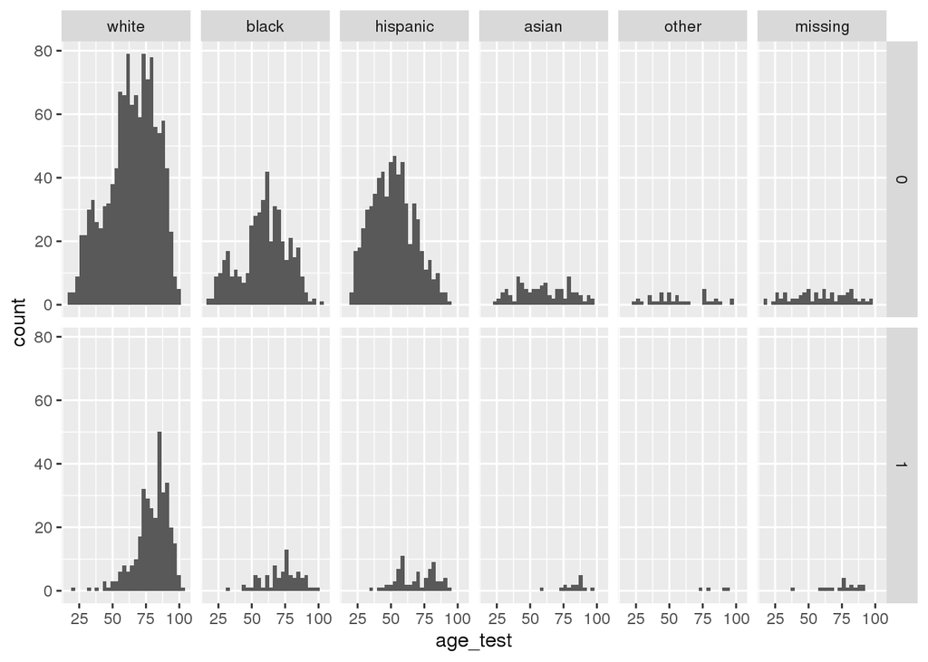

```r
ggplot(death_inpatient_df, aes(x=age_test)) +
  geom_histogram() + facet_grid(death_flag~race_normalized)
```

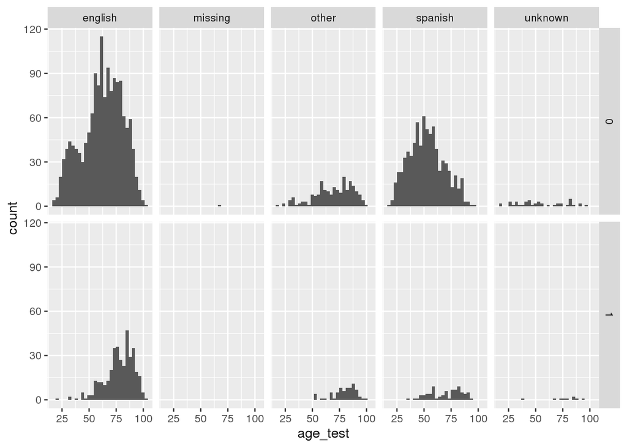

```r
ggplot(death_inpatient_df, aes(x=age_test)) +
  geom_histogram() + facet_grid(death_flag~language_normalized)
```

## Base Model

Code used to run the base model for death due to SARS-CoV-2.

```r
death_matern_base <-  mgcv::gam(
  formula = death_flag ~
    age_test +
    Gender +
    race_normalized +
    language_normalized +
    inscat1 +
    per_capita_testing +
    s(latitude, longitude, bs='gp',  k=100, m=c(3,0.00500)),
  family = binomial(),
  data = death_inpatient_df
)


parameters_death_matern_base <- parameters(death_matern_base,exponentiate=TRUE)




saveRDS(parameters_death_matern_base,
        '/PHShome/cl331/covid_analysis/v3/covid_website/data/parameters_death_matern_base.rds')
```

### All Coefficients

Model statistics for all variables used in base model.

```r
DT::datatable(round_df(parameters_death_matern_base, digits = 2))
```

|  | Parameter | Coefficient | SE | CI_low | CI_high | z | df_error | p | Component |
| --- | --- | --- | --- | --- | --- | --- | --- | --- | --- |
| 1 | (Intercept) | 0 | 0 | 0 | 0 | -16.19 | 2961.62 | 0 | conditional |
| 2 | age_test | 1.06 | 0 | 1.05 | 1.07 | 12.34 | 2961.62 | 0 | conditional |
| 3 | GenderM | 1.64 | 0.18 | 1.32 | 2.04 | 4.49 | 2961.62 | 0 | conditional |
| 4 | race_normalizedblack | 0.86 | 0.14 | 0.62 | 1.19 | -0.91 | 2961.62 | 0.36 | conditional |
| 5 | race_normalizedhispanic | 1.47 | 0.35 | 0.92 | 2.36 | 1.61 | 2961.62 | 0.11 | conditional |
| 6 | race_normalizedasian | 0.58 | 0.19 | 0.3 | 1.12 | -1.62 | 2961.62 | 0.1 | conditional |
| 7 | race_normalizedother | 0.45 | 0.26 | 0.15 | 1.38 | -1.4 | 2961.62 | 0.16 | conditional |
| 8 | race_normalizedmissing | 1.16 | 0.38 | 0.61 | 2.2 | 0.44 | 2961.62 | 0.66 | conditional |
| 9 | language_normalizedmissing | 0 | 0 | 0 |  | 0 | 2961.62 | 1 | conditional |
| 10 | language_normalizedother | 1.25 | 0.24 | 0.85 | 1.82 | 1.15 | 2961.62 | 0.25 | conditional |

[output cut: 7 more lines]

### Coefficients by FDR < 0.05

Model statistics for all variables after filtering (FDR adjusted p-value < 0.05) in base model.

```r
DT::datatable(round_df(parameters_death_matern_base %>% filter(p < 0.05), digits = 2))
```

|  | Parameter | Coefficient | SE | CI_low | CI_high | z | df_error | p | Component |
| --- | --- | --- | --- | --- | --- | --- | --- | --- | --- |
| 1 | (Intercept) | 0 | 0 | 0 | 0 | -16.19 | 2961.62 | 0 | conditional |
| 2 | age_test | 1.06 | 0 | 1.05 | 1.07 | 12.34 | 2961.62 | 0 | conditional |
| 3 | GenderM | 1.64 | 0.18 | 1.32 | 2.04 | 4.49 | 2961.62 | 0 | conditional |
| 4 | inscat12 | 1.87 | 0.27 | 1.4 | 2.48 | 4.3 | 2961.62 | 0 | conditional |

## Base Plus Individal Environmental Variables

Code used to run the base-plus model for death due to SARS-CoV-2 infection. This model iterates through all Census tract variables and fits a model with base variables plus the Census tract variable.

```r
inpatient_regression_df %>% group_by(inpatient_flag,VITAL_STATUS_CD) %>% tally()
```

```
## # A tibble: 4 x 3
## # Groups:   inpatient_flag [2]
##   inpatient_flag VITAL_STATUS_CD     n
##            <dbl> <fct>           <int>
## 1              0 N                6781
## 2              0 Y                  49
## 3              1 N                2485
## 4              1 Y                 524
```

```r
gam_death_matern_base_environment <- as.formula(death_flag ~
    age_test +
    Gender +
    race_normalized +
    language_normalized +
    inscat1 +
    per_capita_testing +
    environmental_value +
    s(latitude, longitude, bs='gp', k=100, m=c(3,0.00500))
    )




#gam_death_parameters_base_environment_list <- furrr::future_map(.x=environmental_variables,
#                                                 .f=safely(gam_estimate_base_environmental_variable),
#                                                 df=death_inpatient_df,
#                                                 formula_matern=gam_death_matern_base_environment)



#saveRDS(gam_death_parameters_base_environment_list, '/PHShome/cl331/covid_analysis/data/v2/gam_death_parameters_base_environment_list.rds')




gam_death_parameters_base_environment_list <- readRDS('/PHShome/cl331/covid_analysis/data/v2/gam_death_parameters_base_environment_list.rds')


gam_death_parameters_base_environment_df_subset <- map(.x=list_nums,
                                                     .f=extract_parameters,
                                                     df=gam_death_parameters_base_environment_list) %>%
  bind_rows() %>% filter(Parameter == 'environmental_value')


gam_death_parameters_base_environment_df_subset_vif <- map(.x=list_nums,
                                                               .f=extract_vif,
                                                               df=gam_death_parameters_base_environment_list) %>%
  bind_rows()
```

```r
FDR_df_death<- gam_death_parameters_base_environment_df_subset %>%
  filter(!Parameter %in% c('age_test','race_normalizedblack','race_normalizedhispanic',
                           'race_normalizedasian','race_normalizedother','race_normalizedmissing',
                           'language_normalizedother','language_normalizedspanish','language_normalizedunknown',
                           'inscat10','inscat11','inscat12','GenderM','GenderU','per_capita_testing',
                           '(Intercept)'))




FDR_df_death_fdr <- FDR_df_death %>%
  mutate(fdr=p.adjust(p, method="fdr")) %>%
  mutate(significance = if_else(fdr < 0.05,'FDR significant', 'FDR not significant')) %>%
  mutate(Parameter=environmental_variable)




saveRDS(FDR_df_death_fdr,
        '/PHShome/cl331/covid_analysis/v3/covid_website/data/FDR_df_death_fdr.rds')
```

### All Coefficients

Model statistics of all Census tract level variables after running all base-plus models.

```r
DT::datatable(round_df(FDR_df_death_fdr, digits = 2))
```

|  | Parameter | Coefficient | SE | CI_low | CI_high | z | df_error | p | Component | environmental_variable | fdr | significance |
| --- | --- | --- | --- | --- | --- | --- | --- | --- | --- | --- | --- | --- |
| 1 | over_65_all_pct | 0.87 | 0.87 | 0.13 | 6.1 | -0.13 | 2960.61 | 0.89 | conditional | over_65_all_pct | 0.93 | FDR not significant |
| 2 | non_white_pct | 1.71 | 0.52 | 0.95 | 3.09 | 1.78 | 2964.04 | 0.08 | conditional | non_white_pct | 0.81 | FDR not significant |
| 3 | white_pct | 0.58 | 0.18 | 0.32 | 1.06 | -1.78 | 2964.04 | 0.08 | conditional | white_pct | 0.81 | FDR not significant |
| 4 | black_pct | 1.4 | 0.68 | 0.54 | 3.61 | 0.69 | 2961.18 | 0.49 | conditional | black_pct | 0.93 | FDR not significant |
| 5 | asian_pct | 1.48 | 1.31 | 0.26 | 8.34 | 0.45 | 2960.15 | 0.66 | conditional | asian_pct | 0.93 | FDR not significant |
| 6 | hispanic_pct | 1.89 | 0.89 | 0.75 | 4.74 | 1.35 | 2962.75 | 0.18 | conditional | hispanic_pct | 0.88 | FDR not significant |
| 7 | foreign_born_pct | 1.35 | 0.74 | 0.46 | 3.96 | 0.55 | 2961.05 | 0.58 | conditional | foreign_born_pct | 0.93 | FDR not significant |
| 8 | pct_private_insurance | 0.54 | 0.22 | 0.24 | 1.21 | -1.49 | 2963.74 | 0.14 | conditional | pct_private_insurance | 0.81 | FDR not significant |
| 9 | pct_medicare_insurance | 0.61 | 0.74 | 0.06 | 6.61 | -0.41 | 2960.64 | 0.68 | conditional | pct_medicare_insurance | 0.93 | FDR not significant |
| 10 | pct_medicaid_insurance | 1.65 | 0.75 | 0.68 | 4.05 | 1.1 | 2962.63 | 0.27 | conditional | pct_medicaid_insurance | 0.93 | FDR not significant |

[output cut: 40 more lines]

### Coefficients by FDR < 0.05

```r
DT::datatable(round_df(FDR_df_death_fdr %>% filter(fdr < 0.05), digits = 2))
```

|  | Parameter | Coefficient | SE | CI_low | CI_high | z | df_error | p | Component | environmental_variable | fdr | significance |
| --- | --- | --- | --- | --- | --- | --- | --- | --- | --- | --- | --- | --- |

## Multivariate Analysis

Code used to run the multivariate analysis for death due to SARS-CoV-2 infection. This model selects all FDR significant Census tract variables from the base plus step and all base variables to fit a single multivariate model.

```r
death_matern_fdr_filtered <-  mgcv::gam(
  formula = death_flag ~
    Gender +
    age_test +
    race_normalized +
    language_normalized +
    inscat1 +
    per_capita_testing +
    s(latitude, longitude, bs='gp', k=100, m=c(3,0.00500)),
  family = binomial(),
  data = death_inpatient_df
)


parameters_death_matern_fdr_filtered<- parameters(death_matern_fdr_filtered,exponentiate=TRUE)




saveRDS(parameters_death_matern_fdr_filtered,
        '/PHShome/cl331/covid_analysis/v3/covid_website/data/parameters_death_matern_fdr_filtered.rds')
```

### All Coefficients

Model statistics of all variables used in multivariate model.

```r
DT::datatable(round_df(parameters_death_matern_fdr_filtered, digits = 2))
```

|  | Parameter | Coefficient | SE | CI_low | CI_high | z | df_error | p | Component |
| --- | --- | --- | --- | --- | --- | --- | --- | --- | --- |
| 1 | (Intercept) | 0 | 0 | 0 | 0 | -16.19 | 2961.62 | 0 | conditional |
| 2 | GenderM | 1.64 | 0.18 | 1.32 | 2.04 | 4.49 | 2961.62 | 0 | conditional |
| 3 | age_test | 1.06 | 0 | 1.05 | 1.07 | 12.34 | 2961.62 | 0 | conditional |
| 4 | race_normalizedblack | 0.86 | 0.14 | 0.62 | 1.19 | -0.91 | 2961.62 | 0.36 | conditional |
| 5 | race_normalizedhispanic | 1.47 | 0.35 | 0.92 | 2.36 | 1.61 | 2961.62 | 0.11 | conditional |
| 6 | race_normalizedasian | 0.58 | 0.19 | 0.3 | 1.12 | -1.62 | 2961.62 | 0.1 | conditional |
| 7 | race_normalizedother | 0.45 | 0.26 | 0.15 | 1.38 | -1.4 | 2961.62 | 0.16 | conditional |
| 8 | race_normalizedmissing | 1.16 | 0.38 | 0.61 | 2.2 | 0.44 | 2961.62 | 0.66 | conditional |
| 9 | language_normalizedmissing | 0 | 0 | 0 |  | 0 | 2961.62 | 1 | conditional |
| 10 | language_normalizedother | 1.25 | 0.24 | 0.85 | 1.82 | 1.15 | 2961.62 | 0.25 | conditional |

[output cut: 7 more lines]

### Coefficients by FDR < 0.05

Model statistics of all variables (after filtering for FDR adjusted p-value < 0.05) used in multivariate model.

```r
DT::datatable(round_df(parameters_death_matern_fdr_filtered %>% filter(p < 0.05), digits = 2))
```

|  | Parameter | Coefficient | SE | CI_low | CI_high | z | df_error | p | Component |
| --- | --- | --- | --- | --- | --- | --- | --- | --- | --- |
| 1 | (Intercept) | 0 | 0 | 0 | 0 | -16.19 | 2961.62 | 0 | conditional |
| 2 | GenderM | 1.64 | 0.18 | 1.32 | 2.04 | 4.49 | 2961.62 | 0 | conditional |
| 3 | age_test | 1.06 | 0 | 1.05 | 1.07 | 12.34 | 2961.62 | 0 | conditional |
| 4 | inscat12 | 1.87 | 0.27 | 1.4 | 2.48 | 4.3 | 2961.62 | 0 | conditional |